# Flipped Classroom Exercises

# What is a flipped classroom?

**“A flipped classroom is an instructional strategy and a type of blended learning, which aims to increase student engagement and learning by having students complete readings at their home and work on live problem-solving during class time .” Source:** https://en.wikipedia.org/wiki/Flipped_classroom

# Learning objectives

1. Create data graphics using the ggplot2 package
2. Identify suitable aesthetics and geoms to create plots using `qplot` and `ggplot`
3. Identify what faceting is and apply faceting in ggplot
4. Customize data graphics using ggplot

# Learning materials

Check the video lectures in Google Classroom.

# Data set

This question is based on `mpg` dataset in the `ggplot2` package. Load the `ggplot2` package and `mpg` dataset using the following command.

```r
library(ggplot2)
data(mpg)
```

Fuel economy data from 1999 to 2008 for 38 popular models of cars.

This dataset contains a subset of the fuel economy data that the EPA makes available on https://fueleconomy.gov/. It contains only models which had a new release every year between 1999 and 2008 - this was used as a proxy for the popularity of the car. To find out more information about the dataset you can run the command

```r
help(mpg) # or ?mpg
```

You can observe the data structure using the following command

```r
str(mpg)
```

```
tibble [234 × 11] (S3: tbl_df/tbl/data.frame)
 $ manufacturer: chr [1:234] "audi" "audi" "audi" "audi" ...
 $ model       : chr [1:234] "a4" "a4" "a4" "a4" ...
 $ displ       : num [1:234] 1.8 1.8 2 2 2.8 2.8 3.1 1.8 1.8 2 ...
 $ year        : int [1:234] 1999 1999 2008 2008 1999 1999 2008 1999 1999 2008 ...
 $ cyl         : int [1:234] 4 4 4 4 6 6 6 4 4 4 ...
 $ trans       : chr [1:234] "auto(l5)" "manual(m5)" "manual(m6)" "auto(av)" ...
 $ drv         : chr [1:234] "f" "f" "f" "f" ...
 $ cty         : int [1:234] 18 21 20 21 16 18 18 18 16 20 ...
 $ hwy         : int [1:234] 29 29 31 30 26 26 27 26 25 28 ...
 $ fl          : chr [1:234] "p" "p" "p" "p" ...
 $ class       : chr [1:234] "compact" "compact" "compact" "compact" ...
```

To get a summary use the command

```r
summary(mpg)
```

```
 manufacturer          model               displ            year
 Length:234         Length:234         Min.   :1.600   Min.   :1999
 Class :character   Class :character   1st Qu.:2.400   1st Qu.:1999
 Mode  :character   Mode  :character   Median :3.300   Median :2004
                                       Mean   :3.472   Mean   :2004
                                       3rd Qu.:4.600   3rd Qu.:2008
                                       Max.   :7.000   Max.   :2008
      cyl           trans               drv                 cty
 Min.   :4.000   Length:234         Length:234         Min.   : 9.00
 1st Qu.:4.000   Class :character   Class :character   1st Qu.:14.00
 Median :6.000   Mode  :character   Mode  :character   Median :17.00
 Mean   :5.889                                         Mean   :16.86
 3rd Qu.:8.000                                         3rd Qu.:19.00
 Max.   :8.000                                         Max.   :35.00
      hwy             fl               class
 Min.   :12.00   Length:234         Length:234
 1st Qu.:18.00   Class :character   Class :character
 Median :24.00   Mode  :character   Mode  :character
 Mean   :23.44
 3rd Qu.:27.00
 Max.   :44.00
```

# Exercise

## Write R codes to reproduce the following plots using both the `qplot` function and the `ggplot` function in the `ggplot2` package. The first one is done for you.

Help:

1. Identify the `x` variable, `y` variable, `color` variable.
2. Identify the geom type: `point`, `hist`, `smooth`, `density`
3. Identify the attribute: `color`, `shape`, etc.

## Plot 1

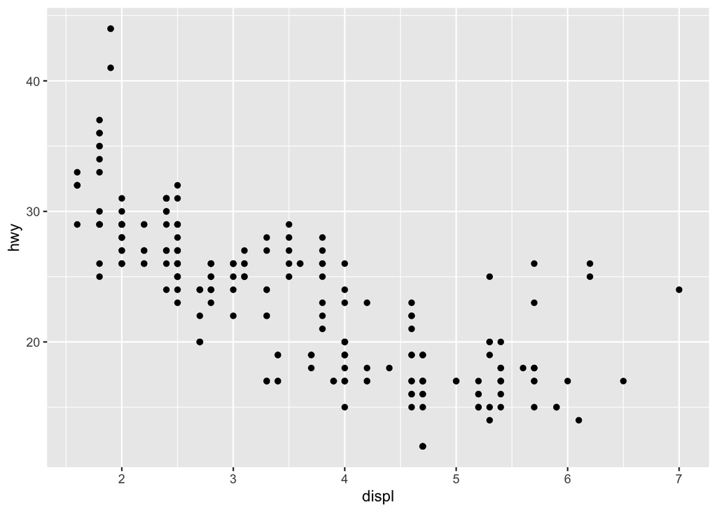

### qplot command:

```r
qplot(displ, hwy, data=mpg, geom="point")
```

### ggplot command:

```r
## method 1
ggplot(data=mpg aes(x=displ, y=hwy)) + geom_point()
## method 2
ggplot(data=mpg) + geom_point(aes(x=displ, y=hwy))
```

## Plot 2

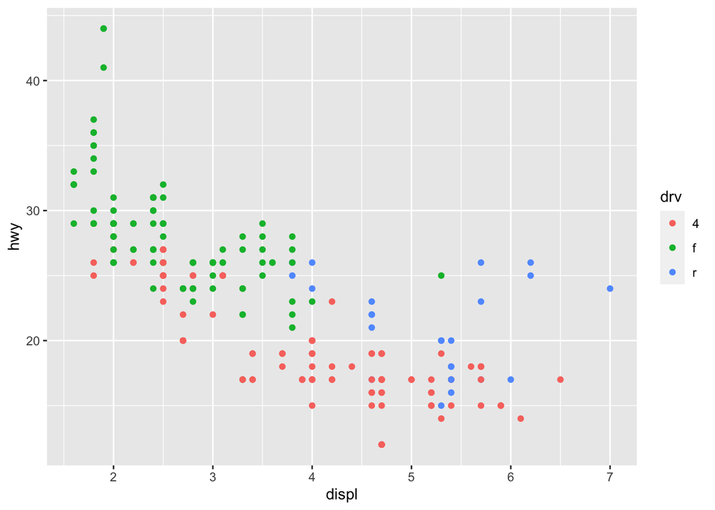

### qplot command:

### ggplot command:

## Plot 3

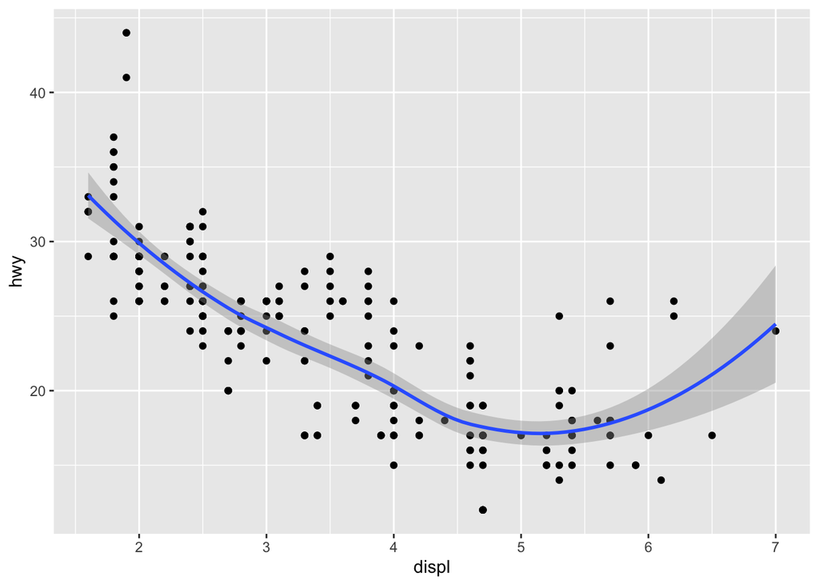

### qplot command:

### ggplot command:

## Plot 4

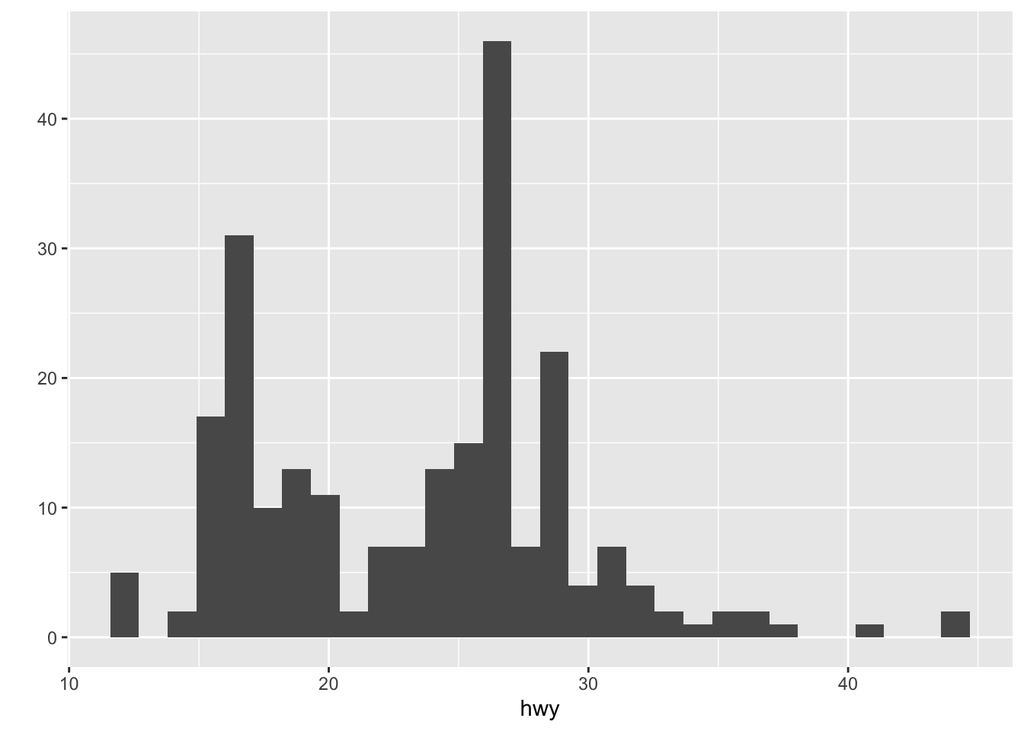

### qplot command:

### ggplot command:

## Plot 5

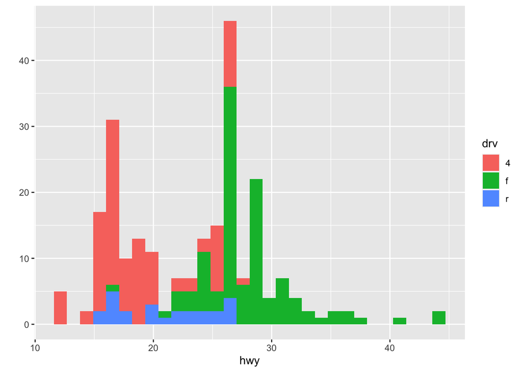

### qplot command:

### ggplot command:

## Plot 6

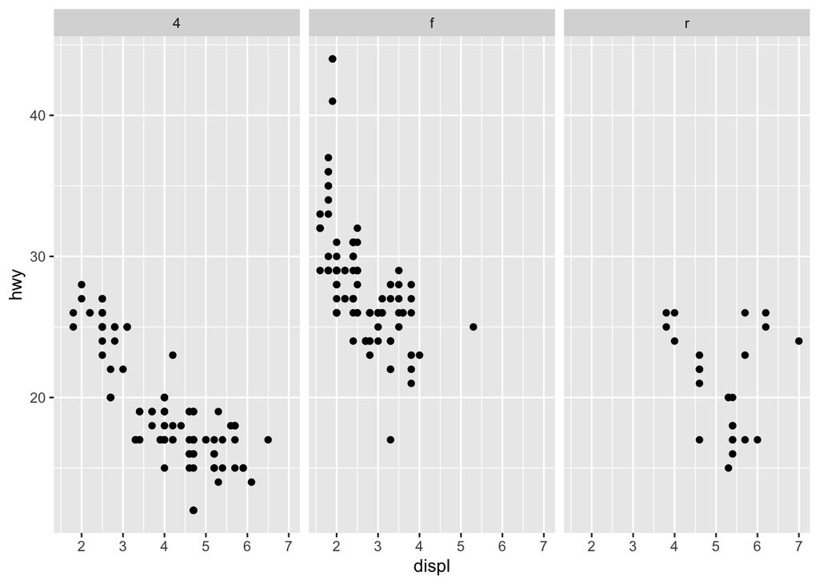

### qplot command:

### ggplot command:

## Plot 6

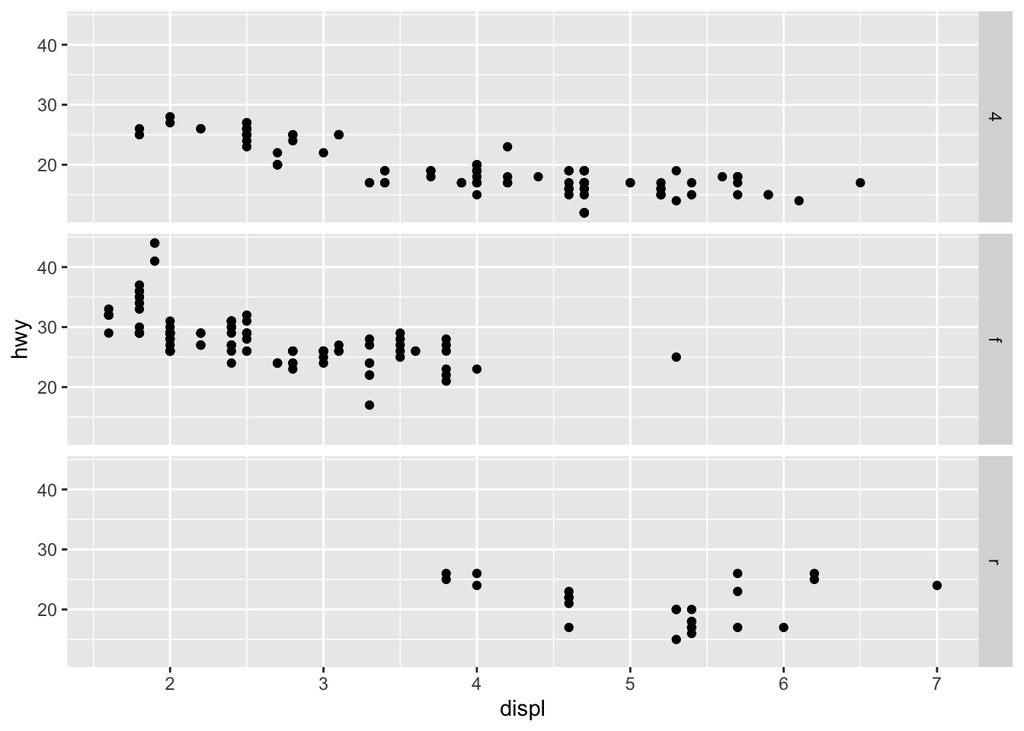

### qplot command:

### ggplot command:

## Plot 7

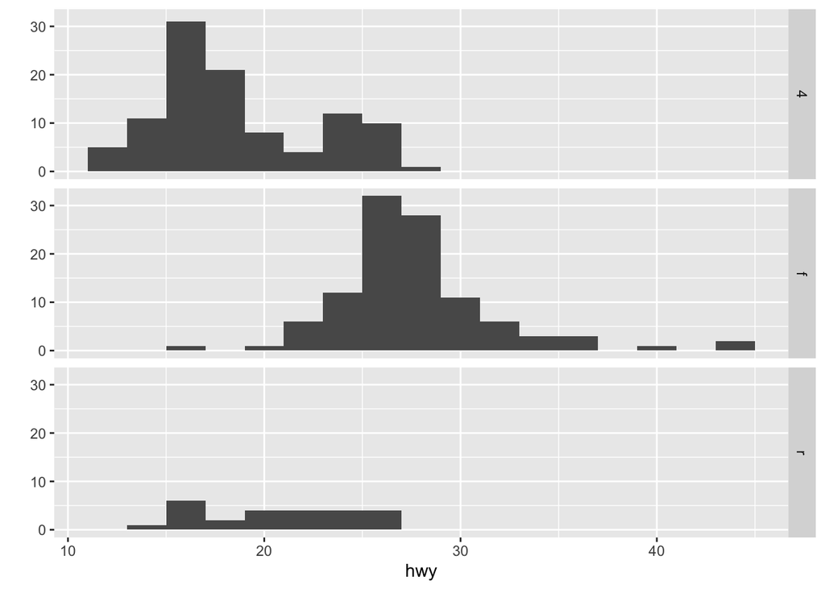

### qplot command:

### ggplot command:

## Plot 8

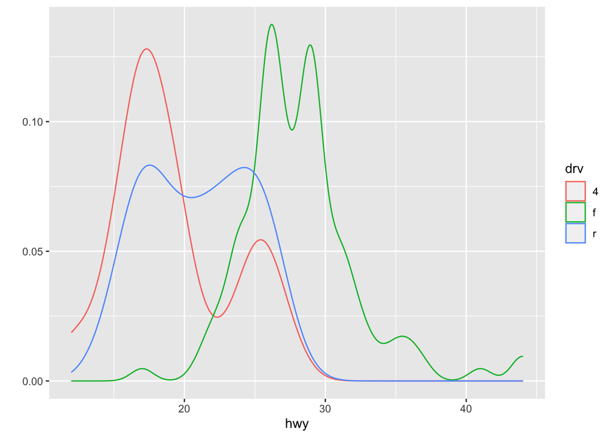

### qplot command:

### ggplot command:

## Plot 9

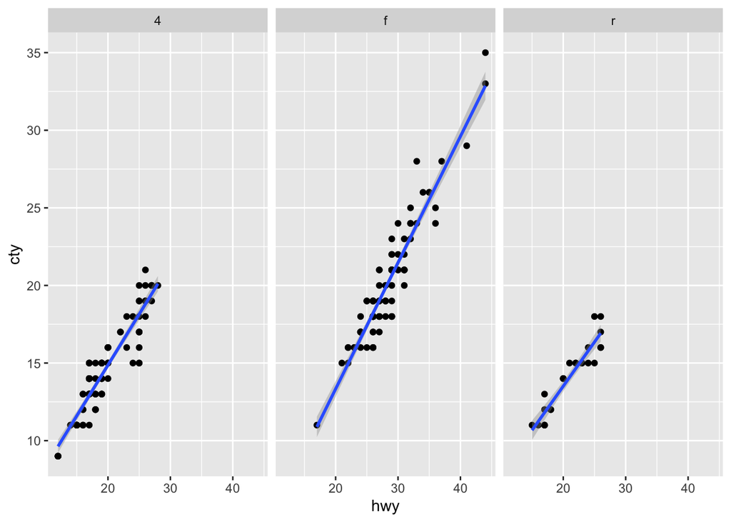

### qplot command:

### ggplot command:

## Plot 10

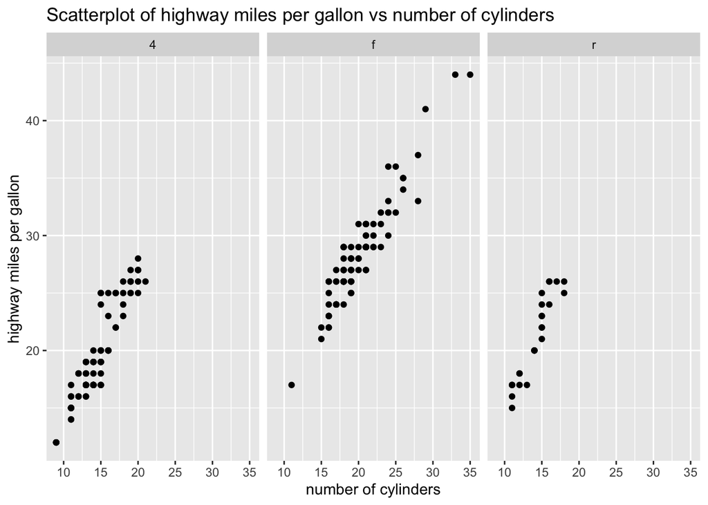

ggplot command only: